# Коинтегральные ряды-Copy2

```python
%matplotlib inline
import matplotlib.pyplot as plt

import numpy as np
import pandas as pd
import seaborn as sns

import statsmodels.api as sm

from sklearn.metrics import mean_squared_error

import os

import warnings
```

```python
warnings.filterwarnings("ignore") # отключает предупреждения
```

Стационарный ряд отличается постоянством средних значений и их дисперсий. В нестационарном ряде максимум, что можно сделать - отследить его тренд.

Нестационарные временные ряды - это почти все ценовые графики финансовых активов, столь широко знакомые любому трейдеру. Бычий тренд, медвежий тренд, экстремумы. Исключение составляет боковой дрейф курса на каком-то периоде.

В особый класс нестационарных рядов выделяют интегрированные, они же разностно-стационарные или DS-ряды (англ. Difference Stationary).

## Коинтегральные ряды

Коинтеграция — свойство нескольких нестационарных (интегрированных) временных рядов, заключающееся в существовании некоторой их стационарной линейной комбинации

коинтеграция рядов - возможность получения стационарного ряда через линейную комбинацию двух (или более) нестационарных интегрированных рядов. Главная мысль состоит в том, чтобы, применяя линейную зависимость, получить из нескольких нестационарных интегрированных рядов, стационарную зависимость.

- https://habr.com/ru/post/332558/

Тест Энгла-Грэнджера на коинтеграцию : последовательность исследования двух временных рядов Xt и Yt на коинтеграцию.

1. Анализируются на стационарность исходные ряды. Если они стационарны, то на этом все заканчивается. Коинтеграция тут ни к чему. Пусть ряды Xt и Yt нестационарны.
2. Далее на стационарность тестируется разность первого порядка исходных рядов. Если она нестационарна, то ряды не являются коинтегральными. В том случае, когда разности первого порядка стационарны и получаются интегрированные ряды первого порядка I(1) (нестационарными рядами со стационарными приращениями - DT(1)) процесс продолжается и переходит к пункту 3.
3. Составляется линейная комбинация: yt-a *xt + c*t + b=εt

где:

- εt - итог линейной комбинации, остаток,
- с - коэффициент линейного тренда,
- а - коэффициент коинтеграции xt c yt
- b - свободный член
- t - время.
- учитывает связь только двух временных рядов.
1. Конечной целью является решение задачи о стационарности ряда εt. “а” подбирают так, чтобы значения εt максимально близко лежали вокруг среднего нулевого уровня, другими словами, обладали минимальным разбросом (дисперсией) относительно него по методу наименьших квадратов (МНК) с Q(a) = min∑εt^2=∑(yt-axt)^2
2. Подобрав оптимальный коэффициент “а”, ряд εt проверяют на стационарность ( тест Дики-Фуллера).

Если ряд εt - стационарный, вида I(0), то имеет место коинтеграция исходных нестационарных рядов (вида I(1)) Xt и Yt.

Для анализа коинтеграции трех и более рядов более уместен тест Йохансена.

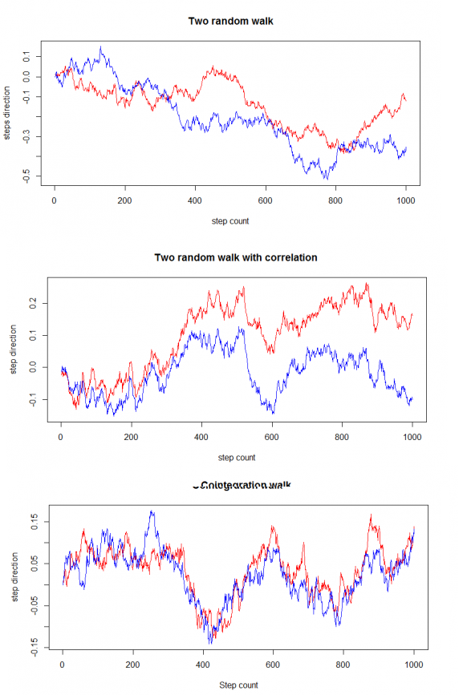

```python
from IPython.display import Image
Image(filename = 'КОИНТЕГРАЦИЯ.png')
```

```python
# VAR пример
from statsmodels.tsa.vector_ar.var_model import VAR

# делаем данные
N = 1000  #  общее число точек
Nt = 100 #  точек для теста
data = []
for i in range(N):
    v1 = 2*np.sin(i/10) + np.random.randn()
    v2 = v1 + np.random.randn()
    row = [v1, v2]
    data.append(row)
# учим модель
data = np.array(data)
model = VAR(data[:-Nt,:]) # создали
model.select_order(15)
model_fit = model.fit(maxlags=15, ic='aic') # обучили
#
model_fit.summary() # предсказали 100 шагов вперед
```

```
  Summary of Regression Results
==================================
Model:                         VAR
Method:                        OLS
Date:           Mon, 09, Nov, 2020
Time:                     18:28:11
--------------------------------------------------------------------
No. of Equations:         2.00000    BIC:                   0.431615
Nobs:                     886.000    HQIC:                  0.238056
Log likelihood:          -2508.75    FPE:                    1.12559
AIC:                     0.118263    Det(Omega_mle):         1.05537
--------------------------------------------------------------------
Results for equation y1
=========================================================================
            coefficient       std. error           t-stat            prob
-------------------------------------------------------------------------
const          0.005677         0.037630            0.151           0.880
L1.y1          0.224359         0.049177            4.562           0.000
L1.y2          0.005465         0.037304            0.147           0.884
L2.y1          0.173935         0.049644            3.504           0.000
L2.y2          0.002887         0.037317            0.077           0.938
L3.y1          0.115614         0.049958            2.314           0.021
L3.y2          0.024982         0.037359            0.669           0.504
L4.y1          0.064016         0.049958            1.281           0.200
L4.y2          0.028293         0.037348            0.758           0.449
L5.y1          0.143444         0.050041            2.867           0.004
L5.y2          0.001831         0.037360            0.049           0.961
L6.y1          0.195618         0.050204            3.897           0.000
L6.y2         -0.037479         0.037309           -1.005           0.315
L7.y1          0.093935         0.050619            1.856           0.063
L7.y2         -0.004059         0.037295           -0.109           0.913
L8.y1          0.056620         0.050645            1.118           0.264
L8.y2          0.004535         0.037256            0.122           0.903
L9.y1          0.016569         0.050373            0.329           0.742
L9.y2          0.002955         0.037269            0.079           0.937
L10.y1        -0.009303         0.050195           -0.185           0.853
L10.y2         0.003310         0.037288            0.089           0.929
L11.y1        -0.028266         0.050002           -0.565           0.572
L11.y2         0.019234         0.037318            0.515           0.606
L12.y1        -0.098269         0.049878           -1.970           0.049
```

[output cut: 31 more lines]

```
L10.y2        -0.026578         0.049241           -0.540           0.589
L11.y1         0.036507         0.066031            0.553           0.580
L11.y2        -0.013218         0.049281           -0.268           0.789
L12.y1        -0.066262         0.065868           -1.006           0.314
L12.y2        -0.000994         0.049409           -0.020           0.984
L13.y1        -0.205052         0.065674           -3.122           0.002
L13.y2         0.054633         0.049337            1.107           0.268
L14.y1        -0.055488         0.065533           -0.847           0.397
L14.y2        -0.076147         0.049291           -1.545           0.122
=========================================================================

Correlation matrix of residuals
            y1        y2
y1    1.000000  0.720704
y2    0.720704  1.000000
```

```python
model_fit.k_ar
```

```
14
```

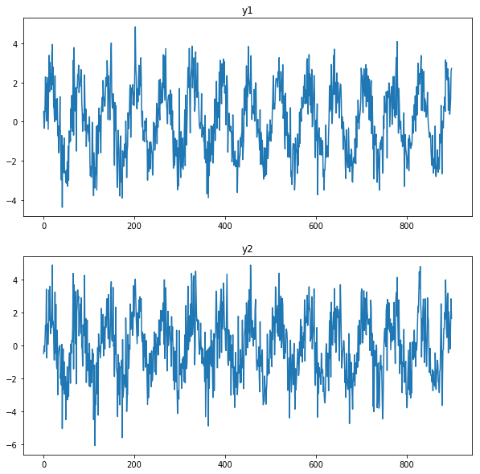

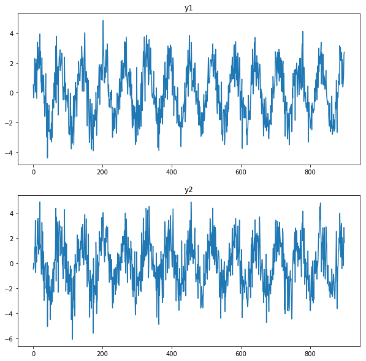

```python
model_fit.plot()
```

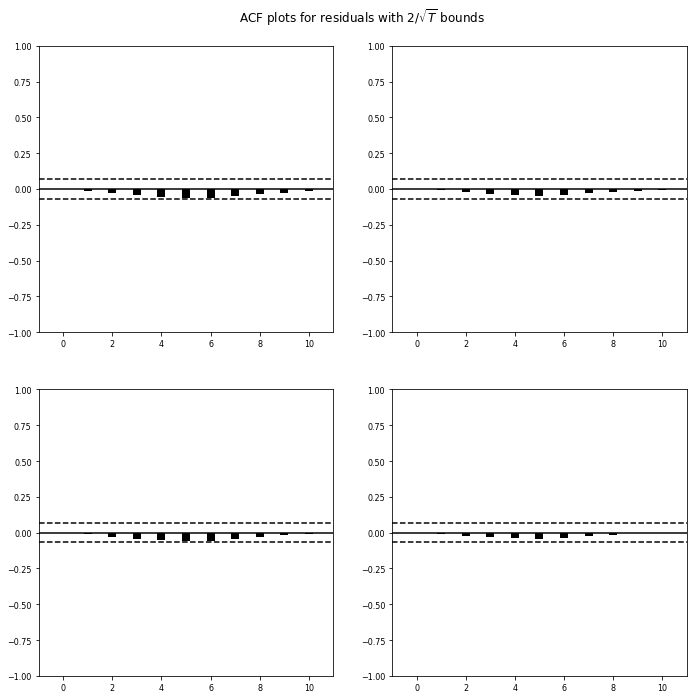

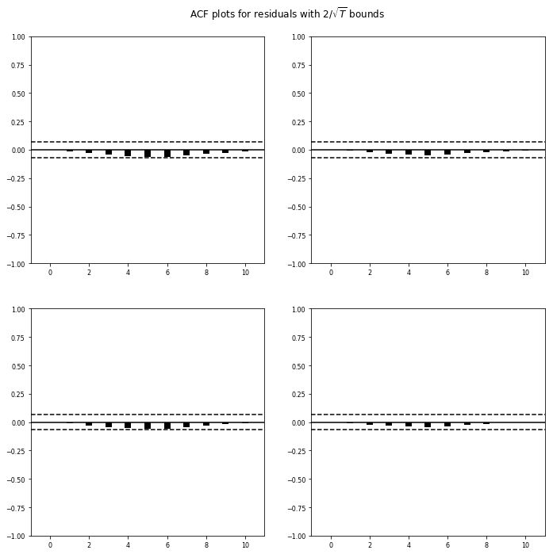

```python
model_fit.plot_acorr()
```

```python
# make prediction
y_pred = model_fit.forecast(model_fit.y, steps=Nt) # предсказали 100 шагов вперед
```

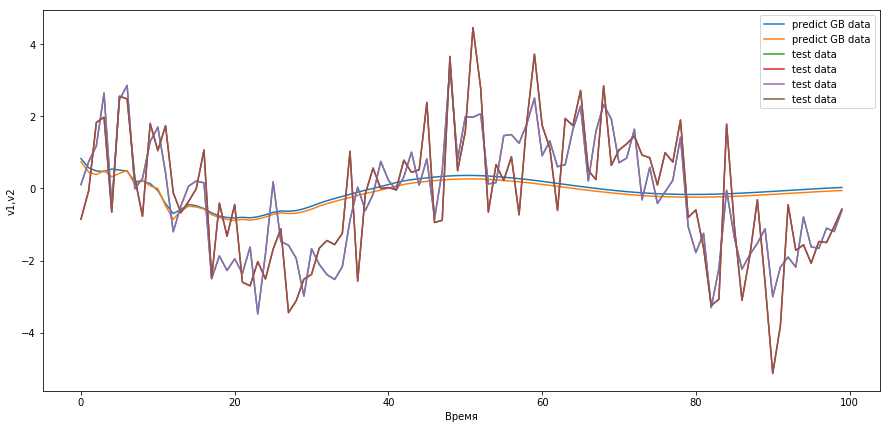

```python
plt.figure( figsize=( 15, 7 ))


plt.xlabel('Время')
plt.ylabel('v1,v2')
plt.plot(y_pred, label='predict GB data' )
plt.plot(data[-Nt:,:], label='test data')

plt.plot(data[-Nt:,:], label='test data')

plt.legend()
plt.show()
```

[output not shown]

```python
# делаем данные


path_brent = 'my_BRENT2019.csv'
brent_data = pd.read_csv(path_brent,sep = ',', index_col=[0], parse_dates=[0])
brent_dataw= brent_data.copy().resample('W').mean()
brent_dataw.drop(brent_dataw.index[:60], inplace=True)
# обходим пропуск


rub_doll=pd.read_excel('RC_F01_09_2010_T01_09_2019.xlsx')
rub_doll.index = pd.to_datetime(rub_doll['data'].values)
rub_doll.drop(['nominal','cdx','data'], axis=1,inplace = True)

rub_doll_w = rub_doll.copy().resample('W').mean()

rub_doll_w.drop(rub_doll_w.index[:60],axis=0,inplace=True)

brent_dataw['doll'] = rub_doll_w['curs']
```

```python
rub_doll_w.index[0]
```

```
Timestamp('2011-10-30 00:00:00', freq='W-SUN')
```

```python
brent_dataw.index[0]
```

```
Timestamp('2011-10-30 00:00:00', freq='W-SUN')
```

```python
brent_dataw['doll'] = rub_doll_w['curs']
brent_dataw.head()
```

| Дата | Значение | year | month | dayofmonth | quarter | dayofyear | weekofyear | dayofweek | is_holiday | is_prev_holiday | is_next_holiday | doll |
| --- | --- | --- | --- | --- | --- | --- | --- | --- | --- | --- | --- | --- |
| 2011-10-30 | 110.680000 | 2011.0 | 10.000000 | 26.666667 | 4.0 | 299.666667 | 43.0 | 2.666667 | 0.000000 | 0.000000 | 0.000000 | 30.407120 |
| 2011-11-06 | 110.820000 | 2011.0 | 10.833333 | 7.833333 | 4.0 | 306.666667 | 44.0 | 2.666667 | 0.000000 | 0.000000 | 0.000000 | 30.574025 |
| 2011-11-13 | 113.225000 | 2011.0 | 11.000000 | 9.666667 | 4.0 | 313.666667 | 45.0 | 2.666667 | 0.166667 | 0.166667 | 0.000000 | 30.509540 |
| 2011-11-20 | 109.565000 | 2011.0 | 11.000000 | 16.666667 | 4.0 | 320.666667 | 46.0 | 2.666667 | 0.000000 | 0.000000 | 0.000000 | 30.689300 |
| 2011-11-27 | 107.341667 | 2011.0 | 11.000000 | 23.666667 | 4.0 | 327.666667 | 47.0 | 2.666667 | 0.166667 | 0.166667 | 0.166667 | 31.251820 |

```python
brent_dataw['doll'].fillna(value = rub_doll_w['curs'].mean(), inplace=True)
```

```python
import statsmodels.formula.api as smf
import statsmodels.tsa.api as smt
import statsmodels.api as sm
import scipy.stats as scs
```

```python
from sklearn.linear_model import LinearRegression
```

```python
lin_reg = LinearRegression()
lin_reg.fit(brent_dataw['doll'].values.reshape(1, -1),brent_dataw['Значение'].values.reshape(1, -1))
y_pred = lin_reg.predict(brent_dataw['doll'].values.reshape(1, -1))
rez=y_pred.reshape(1, -1) - brent_dataw['Значение'].values.reshape(1, -1)
```

```python
ADF_data = sm.tsa.stattools.adfuller(rez[0],regression='ctt')
ADF_data
```

```
(nan,
 nan,
 0,
 409,
 {'1%': -4.399682014519469,
  '5%': -3.8469057579338597,
  '10%': -3.5622402476131656},
 -inf)
```

```python
N = 1000  #  общее число точек
Nt = 100 #  точек для теста
data = []
# учим модель
data = np.array(data)
model = VAR(brent_dataw.loc[:,['Значение', 'doll']].values) # создали
model.select_order(10)
model_fit = model.fit(maxlags=2, ic='aic') # обучили
#
model_fit.summary() # предсказали 100 шагов вперед
```

```
  Summary of Regression Results
==================================
Model:                         VAR
Method:                        OLS
Date:           Mon, 09, Nov, 2020
Time:                     19:16:05
--------------------------------------------------------------------
No. of Equations:         2.00000    BIC:                    3.57670
Nobs:                     408.000    HQIC:                   3.51729
Log likelihood:          -1857.44    FPE:                    32.4075
AIC:                      3.47839    Det(Omega_mle):         31.6276
--------------------------------------------------------------------
Results for equation y1
========================================================================
           coefficient       std. error           t-stat            prob
------------------------------------------------------------------------
const         2.122268         1.653440            1.284           0.199
L1.y1         1.342744         0.046880           28.642           0.000
L1.y2        -0.007738         0.032052           -0.241           0.809
L2.y1        -0.358258         0.047406           -7.557           0.000
L2.y2        -0.011989         0.031813           -0.377           0.706
========================================================================

Results for equation y2
========================================================================
           coefficient       std. error           t-stat            prob
------------------------------------------------------------------------
const         8.998449         2.371727            3.794           0.000
L1.y1        -0.243524         0.067245           -3.621           0.000
L1.y2         0.511437         0.045976           11.124           0.000
L2.y1         0.192661         0.068001            2.833           0.005
L2.y2         0.390989         0.045634            8.568           0.000
========================================================================

Correlation matrix of residuals
            y1        y2
y1    1.000000 -0.090144
y2   -0.090144  1.000000
```